# DataExploration

Avery Chan

10/30/2021

```
svg.selectAll('rect')
  .data(data)
  .enter()
    .append('rect')
      .attr('width', function(d) { return d * 10; })
      .attr('height', '20px')
      .attr('y', function(d, i) { return i * 22; })
      .attr('fill', options.color);
```

[interactive chart not shown]

```r
ui <- fluidPage(
  inputPanel(
    sliderInput("bar_max", label = "Max:",
                min = 0.1, max = 1.0, value = 0.2, step = 0.1)
  ),
  d3Output("d3")
)

server <- function(input, output) {
  output$d3 <- renderD3({
    r2d3(
      runif(5, 0, input$bar_max),
      script = system.file("examples/baranims.js", package = "r2d3")
    )
  })
}

shinyApp(ui = ui, server = server)
```

```
## PhantomJS not found. You can install it with webshot::install_phantomjs(). If it is installed, please make sure the phantomjs executable can be found via the PATH variable.
```

Shiny applications not supported in static R Markdown documents

## Read data

```r
data_Q_activity <- read_csv("1week/Qbserve_byactivity_2021-10-15_2021-10-23.csv", col_types = cols())
data_Q_hour <- read_csv("1week/Qbserve_byhour_2021-10-15_2021-10-23.csv", col_types = cols())
data_T_time <- read_csv("1week/Toggl_time_entries_2021-10-15_to_2021-10-22.csv", col_types = cols())
data_T_summary <- read_csv("1week/Toggl_Track_summary_report_2021-10-15_2021-10-22.csv", col_types = cols())

# calendar data
data_C_Avery <- read_csv("calendar/Avery.csv", col_types = cols())
data_C_Classes <- read_csv("calendar/Classes.csv", col_types = cols())
data_C_System <- read_csv("calendar/System.csv", col_types = cols())
data_C_TimeBlocks <- read_csv("calendar/Time_Blocks.csv", col_types = cols())
```

## Clean data

```r
# convert to time units
data_Q_hour <- data_Q_hour %>%
  mutate(Hour = parse_date_time(Hour, '%I %p') %>%
           # hour() %>%
           hms::as_hms())

data_T_time <- data_T_time %>%
  select(Project,
         Description,
         `Start date`,
         `End date`,
         `Start time`,
         `End time`,
         Duration)
data_T_summary <- data_T_summary %>%
  select(Project, Description, Duration)

# move long column so printing is better
data_Q_activity <-
  data_Q_activity %>% relocate(Name, .after = Category)

data_T_time <- data_T_time %>%
  mutate(Minutes = seconds(Duration) %>% as.numeric() / 60)
data_T_summary <- data_T_summary %>%
  mutate(Minutes = seconds(Duration) %>% as.numeric() / 60)

# data_Q_activity
# data_Q_hour
# data_T_time

# data_T_summary
```

```r
data_Q_activity$Category %>% unique()
```

```
##  [1] "Development"            "Reference & Learning"   "Documents & Writing"
##  [4] "Management"             "News & Blogs"           "Utilities & Services"
##  [7] "Messaging"              "Audio/Video Production" "File Management"
## [10] "Search"                 "General"                "Email"
## [13] "Videos & TV"            "Uncategorized"          "Games"
## [16] "Social"                 "Shopping"               "Leisure"
```

```r
## Add labels

productive <- c("Development", "Documents & Writing", "Reference & Learning", "Email", "Management", "Audio/Video Production")

neutral <- c("Uncategorized", "File Management", "Search", "Utilities & Services", "Messaging")

data_Q_activity <- data_Q_activity %>%
  mutate(
    Type = case_when(
      Category %in% productive ~ "Productive",
      Category %in% neutral ~ "Neutral",
      TRUE ~ "Distracting"
    )
  )
```

## Initial look at Qbserve data

```r
categories <- data_Q_activity %>%
  group_by(Category) %>%
  summarise(n = n(),
            Min = sum(Minutes), Type) %>%
  arrange(-Min)
# categories

app_usage <- data_Q_activity %>%
  group_by(App) %>%
  summarise(n = n(),
            Min = sum(Minutes),
            Type
            ) %>%
  filter(Min > 5) %>%
  arrange(-Min)
```

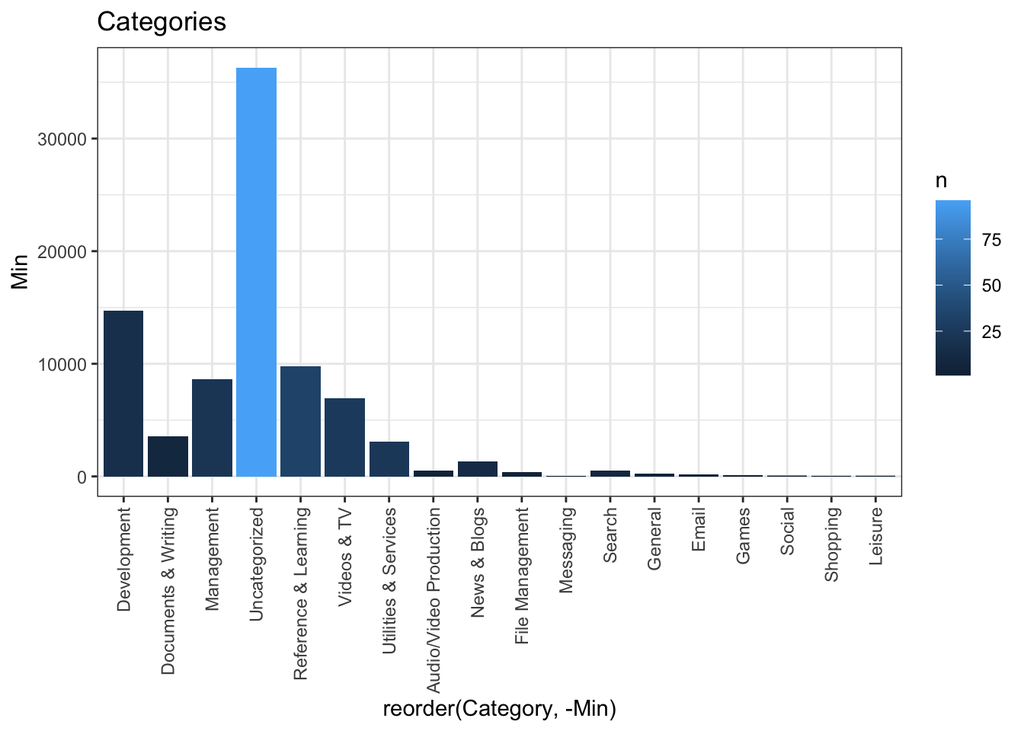

```r
# app_usage

categories %>% ggplot(aes(
  x = reorder(Category,-Min),
  y = Min,
  fill = n
)) +
  geom_col() +
  theme(axis.text.x = element_text(
    angle = 90,
    vjust = 0.5,
    hjust = 1
  )) +
  ggtitle("Categories")
```

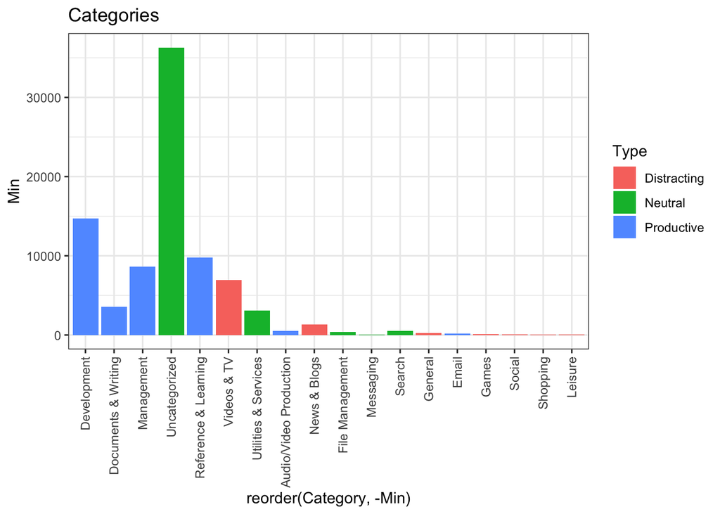

```r
categories %>% ggplot(aes(
  x = reorder(Category,-Min),
  y = Min,
  fill = Type
)) +
  geom_col() +
  theme(axis.text.x = element_text(
    angle = 90,
    vjust = 0.5,
    hjust = 1
  )) +
  ggtitle("Categories")
```

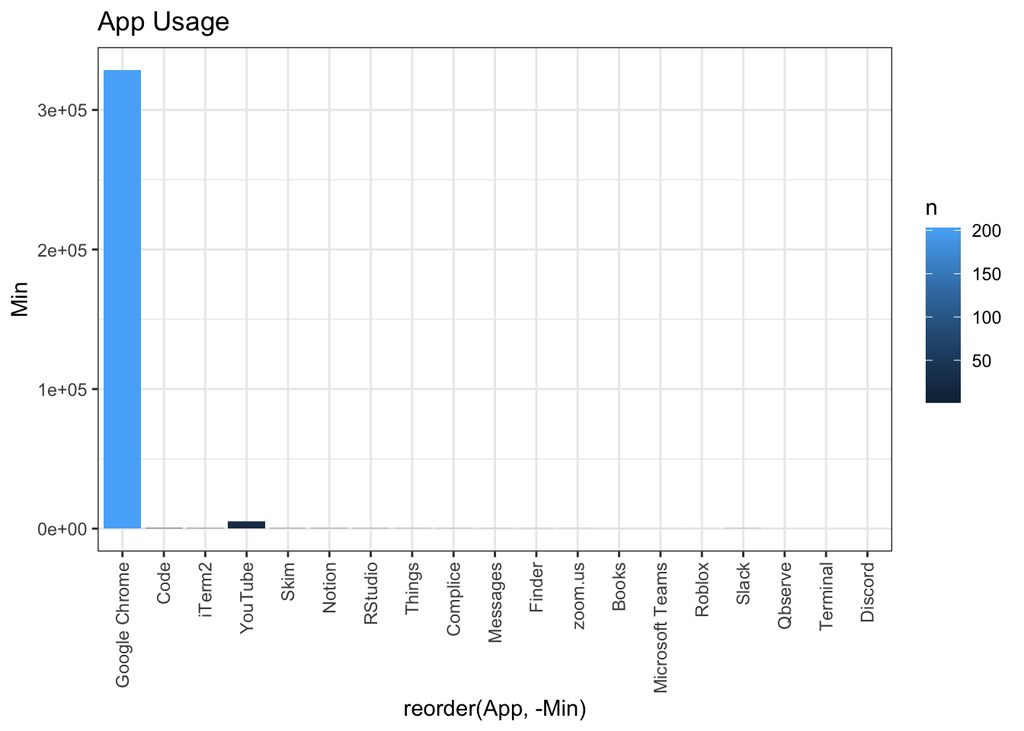

```r
app_usage %>% ggplot(aes(
  x = reorder(App, -Min),
  y = Min,
  fill = n
)) +
  geom_col() +
  theme(axis.text.x = element_text(
    angle = 90,
    vjust = 0.5,
    hjust = 1
  )) + ggtitle("App Usage")
```

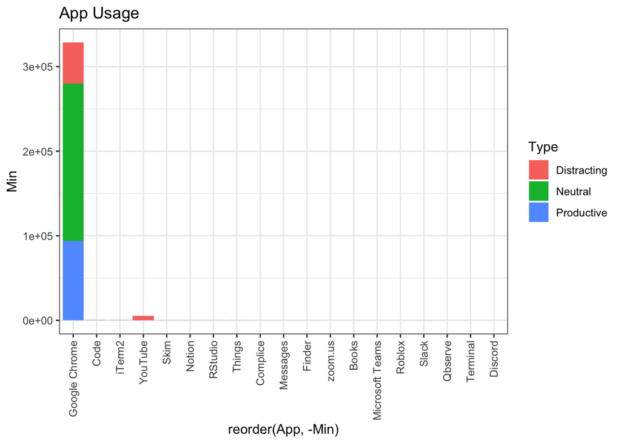

```r
app_usage %>% ggplot(aes(
  x = reorder(App, -Min),
  y = Min,
  fill = Type
)) +
  geom_col() +
  theme(axis.text.x = element_text(
    angle = 90,
    vjust = 0.5,
    hjust = 1
  )) + ggtitle("App Usage")
```

## Initial look at Toggl data

We learn that we can ignore `data_T_summary` since it encodes the same information as `data_T_time`.

```r
## Left over to parse
# data_Q_hour
# data_T_time
# data_T_summary

## Get the same information here
data_T_time_summary <- data_T_time %>%
  group_by(Project, Description) %>%
  summarise(
    Duration = sum(Duration) %>% hms::as_hms(),
    Minutes = sum(Minutes)
  )
# data_T_summary
# They are the same...
data_T_time$Duration %>% sum() == data_T_summary$Duration %>% sum()
```

```
## [1] TRUE
```

First data just around categories.

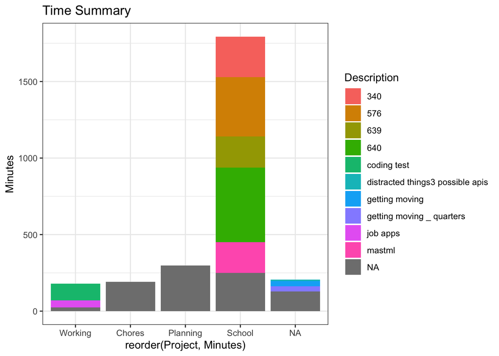

```r
data_T_time_summary %>%
  ggplot(aes(x = reorder(Project, Minutes), y = Minutes, fill=Description)) +
  geom_col() + ggtitle("Time Summary")
```

Then data more temporally. (Calendar might go here)

```r
data_Q_hour
```

| Date | Hour | Total min. | Productive min. | Neutral min. | Distracting min. |
| --- | --- | --- | --- | --- | --- |
| 2021-10-15 | 10:00:00 | 21.7 | 8.1 | 13.6 | 0.0 |
| 2021-10-15 | 11:00:00 | 31.1 | 0.1 | 28.3 | 2.7 |
| 2021-10-15 | 12:00:00 | 44.5 | 11.8 | 29.1 | 3.7 |
| 2021-10-15 | 13:00:00 | 38.7 | 19.7 | 12.9 | 6.1 |
| 2021-10-15 | 15:00:00 | 14.6 | 3.6 | 11.0 | 0.0 |
| 2021-10-15 | 16:00:00 | 47.1 | 44.7 | 2.3 | 0.1 |
| 2021-10-15 | 17:00:00 | 60.0 | 59.1 | 0.9 | 0.0 |
| 2021-10-15 | 18:00:00 | 59.9 | 57.8 | 2.1 | 0.0 |
| 2021-10-15 | 19:00:00 | 13.5 | 13.3 | 0.2 | 0.0 |
| 2021-10-15 | 22:00:00 | 21.5 | 0.5 | 21.0 | 0.0 |

[output cut: 87 more lines]

```r
data_T_time
```

| Project | Description | Start date | End date | Start time | End time | Duration | Minutes |
| --- | --- | --- | --- | --- | --- | --- | --- |
| Planning | NA | 2021-10-15 | 2021-10-15 | 00:29:52 | 01:39:19 | 01:09:27 | 69.450000 |
| NA | getting moving _ quarters | 2021-10-15 | 2021-10-15 | 19:12:10 | 19:44:58 | 00:32:48 | 32.800000 |
| NA | getting moving | 2021-10-15 | 2021-10-15 | 19:45:00 | 20:18:33 | 00:33:33 | 33.550000 |
| School | 576 | 2021-10-15 | 2021-10-16 | 21:13:40 | 00:10:51 | 02:57:11 | 177.183333 |
| Chores | NA | 2021-10-16 | 2021-10-16 | 18:49:15 | 19:50:55 | 01:01:40 | 61.666667 |
| NA | distracted things3 possible apis | 2021-10-16 | 2021-10-16 | 20:19:09 | 20:30:22 | 00:11:13 | 11.216667 |
| Planning | NA | 2021-10-16 | 2021-10-16 | 20:41:05 | 21:18:23 | 00:37:18 | 37.300000 |
| School | 576 | 2021-10-16 | 2021-10-16 | 21:18:36 | 22:40:48 | 01:22:12 | 82.200000 |
| School | 639 | 2021-10-16 | 2021-10-16 | 22:40:49 | 23:45:58 | 01:05:09 | 65.150000 |
| NA | NA | 2021-10-17 | 2021-10-17 | 22:59:46 | 23:47:25 | 00:47:39 | 47.650000 |

[output cut: 38 more lines]

## Requirements

- Static visualization
- A legend that explains the encodings used
- 2-3 paragraphs explain your visualization and the insights that you gain about yourself by creating the visualization

I hoped to learn where my time went. Honestly, I already had the data collection heavily habituatilzed so that’s why I chose it. Additionally, I partially kept up this record keeping because starting a timer incetivises me to work. In some way, it tells me that work has started.

I also noticed that I will start the timer to match when I start working. I don’t know what this means, probably just that it’s a habit. Honestly that’s just motivated by the aspiration for more complete data.

I think more interesting would be a holistic overview that overlays what I did with my records. This would be calendar data and journaling information although I didn’t really do that over this week.

- Overlap (with 5-10m grace) between the two

Honestly, I think I’ll do this next part like an art project I really liked the musical note one What do I need to encode?

- Matching reports
- Mismatch between reports
- Hours
- Category
  - Subcategory
- Sequential time – calendar and start/end (day of week, part of day)